# Análisis exploratorio: estados financieros y características

Alejandro Bedoya - Sebastián Agudelo - Mateo Espinal - Juan Fernando Patiño - Estefanía Echeverry

Junio - 2021

# 1. Pasos previos al análisis

## 1.1. Se cargan las librerías necesarias

```r
library(dplyr)
library(knitr)
library(kableExtra)
library(ggplot2)
library(ggcorrplot)
library(scales)
library(formattable)
options(scipen = 999)
```

## 1.2. Lectura de la base de datos

```r
#Se carga la base de datos
datos_originales <- read.csv("../datos/base_trabajo_segmentacion.csv",
                             sep = ";")

#Se imprime la cabecera
kable(head(datos_originales), "html", align = "c") %>%
    kable_paper("hover", full_width = F) %>%
    row_spec(0, background = "#327CCF", color = "white")%>%
    scroll_box(width = "100%") %>%
    kable_styling(bootstrap_options = c("hover", "condensed"))
```

| nit | en_vm_canal1 | en_vm_canal2 | en_vm_canal3 | en_vm_canal4 | en_vm_canal5 | en_vm_canal6 | en_vm_canal7 | en_vm_canal8 | en_vm_canal9 | en_vm_canal10 | en_vm_otros | en_tx_canal1 | en_tx_canal2 | en_tx_canal3 | en_tx_canal4 | en_tx_canal5 | en_tx_canal6 | en_tx_canal7 | en_tx_canal8 | en_tx_canal9 | en_tx_canal10 | en_tx_otros | sal_vm_canal5 | sal_vm_canal2 | sal_vm_canal8 | sal_vm_otros | sal_tx_canal5 | sal_tx_canal2 | sal_tx_canal8 | … |
| --- | --- | --- | --- | --- | --- | --- | --- | --- | --- | --- | --- | --- | --- | --- | --- | --- | --- | --- | --- | --- | --- | --- | --- | --- | --- | --- | --- | --- | --- | --- |
| C4936394968152386565 | 0 | 0 | 0 | 0 | 0 | 0 | 0 | 0 | 0 | 0 | 0 | 0.000000 | 0.000000 | 0.000000 | 0.00000 | 0.000000 | 0.00 | 0.00 | 0.0 | 0 | 0 | 0 | 0 | 0 | 0 | 0 | 0.000000 | 0.00000 | 0 | … |
| C-8615176103348111575 | 0 | 0 | 0 | 0 | 0 | 0 | 0 | 0 | 0 | 0 | 0 | 0.000000 | 0.000000 | 0.000000 | 0.00000 | 0.000000 | 0.00 | 0.00 | 0.0 | 0 | 0 | 0 | 0 | 0 | 0 | 0 | 0.000000 | 0.00000 | 0 | … |
| C2364605246729357060 | 250927493 | 54160892 | 5122152 | 41852510 | 413614315 | 1663236 | 2106847525 | 0 | 0 | 0 | 0 | 24.416667 | 11.916667 | 3.333333 | 237.83333 | 2.545454 | 5.40 | 8.25 | 0.0 | 0 | 0 | 0 | 413614315 | 2265361194 | 0 | 0 | 2.545454 | 613.08333 | 0 | … |
| C7393816976826597531 | 39402360 | 96468998 | 8226710 | 0 | 0 | 7072802 | 0 | 9000000 | 0 | 0 | 0 | 14.416667 | 13.833333 | 4.600000 | 0.00000 | 0.000000 | 2.80 | 0.00 | 1.0 | 0 | 0 | 0 | 0 | 60558440 | 0 | 0 | 0.000000 | 10.33333 | 0 | … |
| C872645851723947566 | 337432319 | 234217927 | 105344054 | 15755287 | 0 | 23671840 | 0 | 3600962 | 3727299 | 0 | 0 | 153.583333 | 42.250000 | 102.416667 | 49.33333 | 0.000000 | 18.00 | 0.00 | 2.2 | 4 | 0 | 0 | 0 | 0 | 0 | 622080714 | 0.000000 | 0.00000 | 0 | … |
| C-3870380727390720970 | 33629514 | 42883291 | 1348792 | 0 | 0 | 3828360 | 0 | 0 | 687244 | 0 | 0 | 7.416667 | 8.833333 | 1.000000 | 0.00000 | 0.000000 | 1.25 | 0.00 | 0.0 | 1 | 0 | 0 | 0 | 1960611436 | 0 | 0 | 0.000000 | 90.00000 | 0 | … |

## 1.3. Creación de funciones necesarias

**Función encargada de crear las tablas de frecuencias**

```r
#Se defne la función para crear tablas de frecuencia
crear_tabla <- function(datos, columna){

    columna <- enquo(columna)

    #Se halla la frecuencia absoluta a partir de la función count
    tabla_frecuencias <- count(datos, !!columna)

    #Se halla la frecuencia absoluta acumulada, relativa y relativa acumulada
    tabla_frecuencias <- tabla_frecuencias %>% mutate(N = cumsum(n),
                                                      Fr = n/sum(n),
                                                      Fa = cumsum(Fr))

    #Se redondea el resultado de las frecuencias relativas a 4 digitos
    tabla_frecuencias <- tabla_frecuencias %>% mutate(Fr = round(Fr, 4),
                                                      Fa = round(Fa, 4))
    #Se retorna la tabla de frecuencias
    return(tabla_frecuencias)
}
```

**Función encargada de mostrar las tablas de frecuencias**

```r
#Se define la función encargada de mostrar las tablas de frecuencias
mostrar_tabla <- function(tabla){

    #Se extrae el nombre de la variable
    nombre_col <- colnames(tabla)[1]

    #Se crean los nombres en español para la tabla
    nombres_tabla <- c(nombre_col,
                       "Frecuencia absoluta",
                       "Frecuencia absoluta acumulada",
                       "Frecuencia relativa",
                       "Frecuencia relativa acumulada")

    #Se estiliza la tabla con la función kable
    kable(tabla, col.names = nombres_tabla, align = "c",  "html") %>%
        #Se utiliza el tema kable_papper
        kable_paper("hover", full_width = TRUE) %>%
        kable_styling(bootstrap_options = c("hover", "condensed"),
                      font_size = 16) %>%
        row_spec(0, background = "#327CCF", color = "white")
}
```

**Función encargada de crear los gráficos de barras**

```r
#Se define la función para crear los gráficos de barras
grafico_barras <- function(tabla, etiqueta_x){

    #Se crea un nuevo gráfico de ggplot
    ggplot(data = tabla)+
        #Se define el gráfico de barras
        geom_bar(
            aes(x = tabla[, 1], y = Fr),    #Se definen las variables a graficar
            stat = "identity",              #Se grafica la identidad x vs y
            fill="#327CCF",                 #Se define el color de las barras
            alpha=0.5,                      #Se define la transparencia
            col='black'                     #Se define el borde de las barras
        )+
        #Se crea la etiqueta del eje x
        ylab("frecuencia relativa")+
        #Se crea la etiqueta del eje y
        xlab(etiqueta_x)+
        #Se crea el titulo del grafico
        ggtitle(
            paste("Gráfico de barras de",
                  etiqueta_x)
        )+
        #Se crean las etiquetas de los porcentajes para cada barra
        geom_text(
            aes(tabla[, 1], Fr, label=paste0((Fr*100), "%")),
            vjust = 1.15)+
        #Se utiliza el tema bw de ggplot
        theme_bw()+
        #Se ajustan la alineación del titulo y las etiquetas del eje x
        theme(plot.title = element_text(hjust = 0.5))+
        scale_x_continuous(breaks = tabla[, 1])
}
```

**Función encargada de presentar los resúmenes numéricos**

```r
#Se define la función para presentar los resumenes numéricos
resumen <- function(columna){
    #Se usa la función summary para encontrar los resumenes
    summary_canal <- round(summary(columna),4)

    #Se convierte a array y se transpone el resumen numérico
    summary_canal <- t(summary_canal)

    #Se calcula la cantidad de ceros de la variable
    ceros <- sum(columna == 0)

    #Se calcula la proporción de ceros para cada variable
    prop_ceros <- ceros/length(columna)

    #Se convierte la proporción de ceros a escala de porcentaje
    prop_ceros <- round(prop_ceros,4)*100

    #Se añade el simbolo de porcentaje a la proporción de eros
    prop_ceros <- paste0(prop_ceros,"%")

    #Se concatena el resumen numerico con la cantidad y la proporción de ceros
    summary_canal <- cbind(summary_canal, ceros, prop_ceros)

    #Se crean los nombres en español para los resumenes
    nombres_resumen <- c("Mínimo", "Q1", "Mediana", "Media", "Q3",
                         "Máximo", "Ceros", "Proporcion ceros")

    #Se estiliza el resumen con la función kable
    kable(summary_canal, col.names = nombres_resumen, align = "c",  "html") %>%
        #Se utiliza el tema kable_papper
        kable_paper("hover", full_width = TRUE) %>%
        kable_styling(bootstrap_options = c("hover", "condensed"),
                      font_size = 16) %>%
        row_spec(0, background = "#327CCF", color = "white")
}
```

**Función encargada de realizar los histogramas**

```r
#Se crea la función para dibujar los gráficos
crear_grafico <- function(datos, columna, bins=30, etiqueta_x){

    columna = enquo(columna)

    #Se crea el histograma
    grafico <- ggplot(datos, aes(x = !!columna)) +
        geom_histogram(bins = bins, fill="#327CCF", alpha = 0.4, col = "Black")+
        #Se añade la etiqueta del eje x
        xlab(etiqueta_x) +
        #Se añade la etiqueta del eje y
        ylab("Frecuencia") +
        #Se añade la etiqueta del titulo
        ggtitle(
            paste(
              "Histograma de",
              etiqueta_x)
        )+
        theme_bw()+
        #Se centra el titulo
        theme(plot.title = element_text(hjust = 0.5))

    return(grafico)
}
```

# 2. Análisis de variables categóricas ordinales

## 2.1. `impo_cv`

```r
tabla_frecuencias <- crear_tabla(datos_originales, impo_cv)
mostrar_tabla(tabla_frecuencias)
```

| impo_cv | Frecuencia absoluta | Frecuencia absoluta acumulada | Frecuencia relativa | Frecuencia relativa acumulada |
| --- | --- | --- | --- | --- |
| 1 | 824 | 824 | 0.3690 | 0.3690 |
| 2 | 828 | 1652 | 0.3708 | 0.7398 |
| 3 | 306 | 1958 | 0.1370 | 0.8768 |
| 4 | 229 | 2187 | 0.1026 | 0.9794 |
| 5 | 46 | 2233 | 0.0206 | 1.0000 |

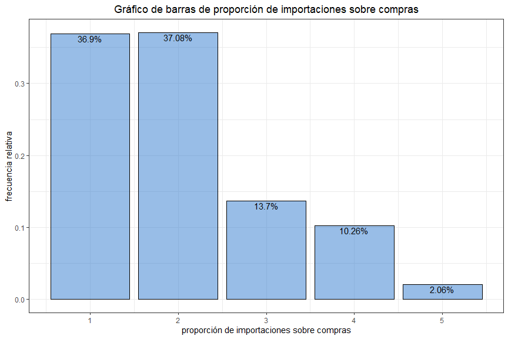

```r
grafico_barras(tabla_frecuencias, "proporción de importaciones sobre compras")
```

La variable `impo_cv` almacena la proporción de compras que se han realizado a través de importaciones $\frac{importaciones}{compras}$, esta se encuentra categorizada de forma ordinal en 5 niveles, donde el nivel 1 representa la proporción más baja y el nivel 5 representa la más alta, por ello para el análisis se utiliza la siguiente redefinición:

- 1 = Bajo
- 2 = Moderadamente bajo
- 3 = Medio
- 4 = Moderadamente alto
- 5 = Alto

El gráfico de barras y la tabla de frecuencias nos muestra que alrededor del 36.9% de observaciones están agrupadas en el nivel 1 y aproximadamente del 37.08% en el nivel dos, reflejando que la mayoría de las empresas (el 73.98%) presentan una baja o moderadamente baja proporción de imporaciones respecto a sus compras totales, adicionalmente, el valor del nivel 5 nos indica que tan solo el 2.06% importa la mayor parte de su materia prima.

## 2.2. `expo_vt`

```r
tabla_frecuencias <- crear_tabla(datos_originales, expo_vt)
mostrar_tabla(tabla_frecuencias)
```

| expo_vt | Frecuencia absoluta | Frecuencia absoluta acumulada | Frecuencia relativa | Frecuencia relativa acumulada |
| --- | --- | --- | --- | --- |
| 1 | 824 | 824 | 0.3690 | 0.3690 |
| 2 | 1225 | 2049 | 0.5486 | 0.9176 |
| 3 | 184 | 2233 | 0.0824 | 1.0000 |

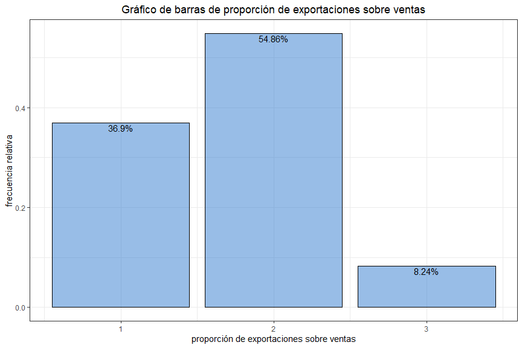

```r
grafico_barras(tabla_frecuencias, "proporción de exportaciones sobre ventas")
```

La variable `expo_vt` almacena la proporción de ventas que se han sido exportadas $\frac{exportaciones}{ventas}$, esta se encuentra categorizada de forma ordinal en 3 niveles, donde el nivel 1 representa la proporción más baja y el nivel 3 representa la más alta, por ello para el análisis se utiliza la siguiente redefinición:

- 1 = Bajo
- 2 = Medio
- 3 = Alto

## 2.3. `cxp`

```r
tabla_frecuencias <- crear_tabla(datos_originales, cxp)
mostrar_tabla(tabla_frecuencias)
```

| cxp | Frecuencia absoluta | Frecuencia absoluta acumulada | Frecuencia relativa | Frecuencia relativa acumulada |
| --- | --- | --- | --- | --- |
| 1 | 487 | 487 | 0.2181 | 0.2181 |
| 2 | 729 | 1216 | 0.3265 | 0.5446 |
| 3 | 362 | 1578 | 0.1621 | 0.7067 |
| 4 | 162 | 1740 | 0.0725 | 0.7792 |
| 5 | 102 | 1842 | 0.0457 | 0.8249 |
| 6 | 391 | 2233 | 0.1751 | 1.0000 |

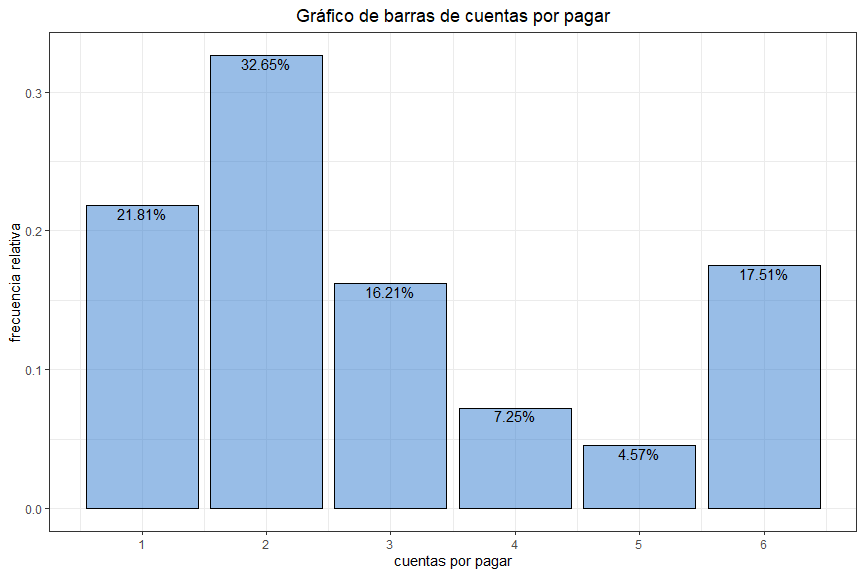

```r
grafico_barras(tabla_frecuencias, "cuentas por pagar")
```

La variable `cxp` representa las cuentas por pagar de cada empresa, esta se encuentra categorizada de forma ordinal en 6 niveles, donde el nivel 1 simboliza la cantidad más baja y el nivel 6 simboliza la más alta, por ello para el análisis se utiliza la siguiente redefinición:

- 1 = Bajo
- 2 = Moderadamente bajo
- 3 = Medio bajo
- 4 = Medio Alto
- 5 = Moderadamente alto
- 6 = Alto

Del gráfico de barras y la tabla de frecuencias observamos que el 32.65% de los clientes presentan una cantidad moderadamente baja de cuentas por pagar y el 21.81% presenta una cantidad baja, esto nos indica que la mayor parte de las empresas tienen un bajo número de obligaciones financieras, sin embargo, es destacable que el 17.51% se encuentren en el nivel más alto.

## 2.4. `cxc`

```r
tabla_frecuencias <- crear_tabla(datos_originales, cxc)
mostrar_tabla(tabla_frecuencias)
```

| cxc | Frecuencia absoluta | Frecuencia absoluta acumulada | Frecuencia relativa | Frecuencia relativa acumulada |
| --- | --- | --- | --- | --- |
| 1 | 324 | 324 | 0.1451 | 0.1451 |
| 2 | 543 | 867 | 0.2432 | 0.3883 |
| 3 | 414 | 1281 | 0.1854 | 0.5737 |
| 4 | 180 | 1461 | 0.0806 | 0.6543 |
| 5 | 164 | 1625 | 0.0734 | 0.7277 |
| 6 | 608 | 2233 | 0.2723 | 1.0000 |

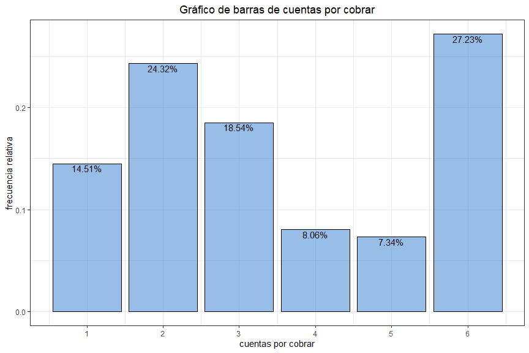

```r
grafico_barras(tabla_frecuencias, "cuentas por cobrar")
```

La variable `cxc` representa las cuentas por cobrar de cada empresa, esta se encuentra categorizada de forma ordinal en 6 niveles, donde el nivel 1 simboliza la cantidad más baja y el nivel 6 simboliza la más alta, por ello para el análisis se utiliza la siguiente redefinición:

- 1 = Bajo
- 2 = Moderadamente bajo
- 3 = Medio bajo
- 4 = Medio Alto
- 5 = Moderadamente alto
- 6 = Alto

## 2.5. `totalinventory`

```r
tabla_frecuencias <- crear_tabla(datos_originales, totalinventory)
mostrar_tabla(tabla_frecuencias)
```

| totalinventory | Frecuencia absoluta | Frecuencia absoluta acumulada | Frecuencia relativa | Frecuencia relativa acumulada |
| --- | --- | --- | --- | --- |
| 1 | 379 | 379 | 0.1697 | 0.1697 |
| 2 | 579 | 958 | 0.2593 | 0.4290 |
| 3 | 368 | 1326 | 0.1648 | 0.5938 |
| 4 | 215 | 1541 | 0.0963 | 0.6901 |
| 5 | 150 | 1691 | 0.0672 | 0.7573 |
| 6 | 542 | 2233 | 0.2427 | 1.0000 |

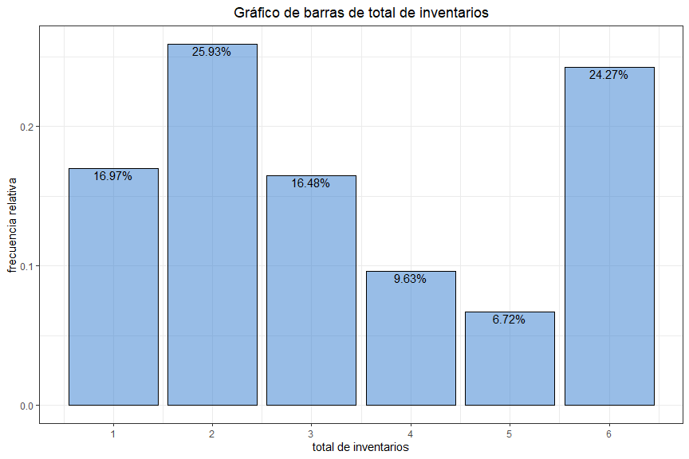

```r
grafico_barras(tabla_frecuencias, "total de inventarios")
```

La variable `totalinventory` representa el valor de inventarios de cada empresa, esta se encuentra categorizada de forma ordinal en 6 niveles, donde el nivel 1 simboliza la cantidad más baja y el nivel 6 simboliza la más alta, por ello para el análisis se utiliza la siguiente redefinición:

- 1 = Bajo
- 2 = Moderadamente bajo
- 3 = Medio bajo
- 4 = Medio Alto
- 5 = Moderadamente alto
- 6 = Alto

Del gráfico de barras y la tabla de frecuencias observamos que el 25.93% de los clientes presentan un total de inventarios moderadamente bajo, mientras que el 24.27% presenta la cantidad más alta. La mayor parte de las empresas (el 59.38%) se encuentran en los tres primeros niveles, reflejando que es más común tener valores bajos, moderadamente bajos o medio bajos en el total de inventarios.

## 2.6. `tiene_ventas_fisicas`

```r
tabla_frecuencias <- crear_tabla(datos_originales, tiene_ventas_fisicas)
mostrar_tabla(tabla_frecuencias)
```

| tiene_ventas_fisicas | Frecuencia absoluta | Frecuencia absoluta acumulada | Frecuencia relativa | Frecuencia relativa acumulada |
| --- | --- | --- | --- | --- |
| 0 | 1171 | 1171 | 0.5244 | 0.5244 |
| 1 | 1062 | 2233 | 0.4756 | 1.0000 |

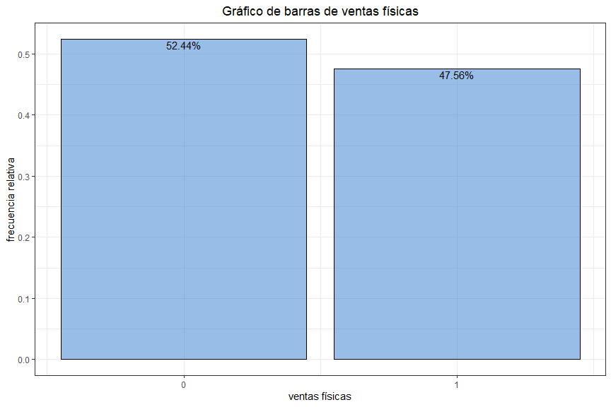

```r
grafico_barras(tabla_frecuencias, "ventas físicas")
```

La variable `tiene_ventas_fisicas` establece si la empresa tiene o no ventas físicas, donde:

- No = 0
- Si = 1.

Del gráfico de barras y la tabla de frecuencias observamos que el 52.44% no poseen ventas físicas y el 47.56% si las posee.

## 2.7. `tiene_ventas_electronicas`

```r
tabla_frecuencias <- crear_tabla(datos_originales, tiene_ventas_electronicas)
mostrar_tabla(tabla_frecuencias)
```

| tiene_ventas_electronicas | Frecuencia absoluta | Frecuencia absoluta acumulada | Frecuencia relativa | Frecuencia relativa acumulada |
| --- | --- | --- | --- | --- |
| 0 | 2121 | 2121 | 0.9498 | 0.9498 |
| 1 | 112 | 2233 | 0.0502 | 1.0000 |

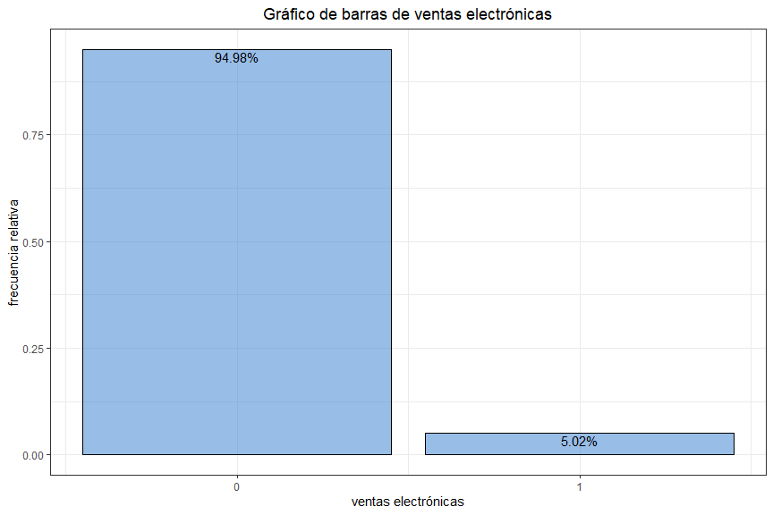

```r
grafico_barras(tabla_frecuencias, "ventas electrónicas")
```

La variable `tiene_ventas_electronicas` establece si la empresa tiene o no ventas electrónicas, donde:

- No = 0
- Si = 1.

Del gráfico de barras y la tabla de frecuencias observamos que la gran mayoría de las empresas no poseen ventas electrónicas y que tan solo el 5.02% si las poseen.

## 2.8. `rotacion_inventarios`

```r
tabla_frecuencias <- crear_tabla(datos_originales, rotacion_inventarios)
mostrar_tabla(tabla_frecuencias)
```

| rotacion_inventarios | Frecuencia absoluta | Frecuencia absoluta acumulada | Frecuencia relativa | Frecuencia relativa acumulada |
| --- | --- | --- | --- | --- |
| 1 | 654 | 654 | 0.2929 | 0.2929 |
| 2 | 413 | 1067 | 0.1850 | 0.4778 |
| 3 | 329 | 1396 | 0.1473 | 0.6252 |
| 4 | 218 | 1614 | 0.0976 | 0.7228 |
| 5 | 147 | 1761 | 0.0658 | 0.7886 |
| 6 | 472 | 2233 | 0.2114 | 1.0000 |

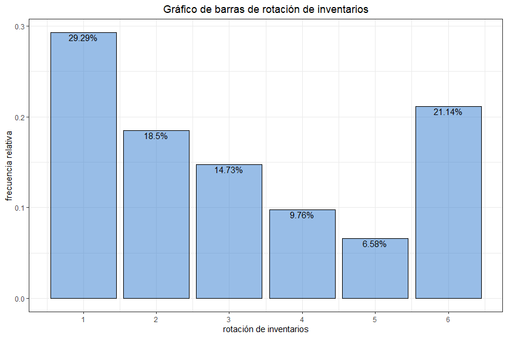

```r
grafico_barras(tabla_frecuencias, "rotación de inventarios")
```

La variable `rotacion_inventarios` representa la rotación de inventarios en días para cada empresa, esta se encuentra categorizada de forma ordinal en 6 niveles, donde el nivel 1 simboliza la rotación más corta y el nivel 6 simboliza la más larga, por ello para el análisis se utiliza la siguiente redefinición:

- 1 = Corto
- 2 = Moderadamente corto
- 3 = Medio corto
- 4 = Medio largo
- 5 = Moderadamente largo
- 6 = Largo

Del gráfico de barras y la tabla de frecuencias observamos que el 29.29% de los clientes presentan una corta rotación de inventarios, que va decreciendo para cada categoría a excepción del nivel 6, el cual nos muestra que el 21.14% de las empresas presenta una rotación larga.

## 2.9. `rotacion_cxc`

```r
tabla_frecuencias <- crear_tabla(datos_originales, rotacion_cxc)
mostrar_tabla(tabla_frecuencias)
```

| rotacion_cxc | Frecuencia absoluta | Frecuencia absoluta acumulada | Frecuencia relativa | Frecuencia relativa acumulada |
| --- | --- | --- | --- | --- |
| 1 | 643 | 643 | 0.2880 | 0.2880 |
| 2 | 596 | 1239 | 0.2669 | 0.5549 |
| 3 | 427 | 1666 | 0.1912 | 0.7461 |
| 4 | 567 | 2233 | 0.2539 | 1.0000 |

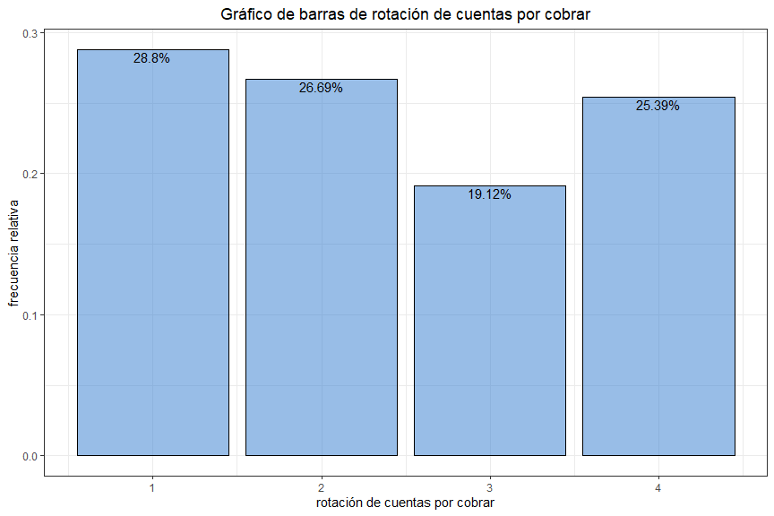

```r
grafico_barras(tabla_frecuencias, "rotación de cuentas por cobrar")
```

La variable `rotacion_cxc` representa la rotación de las cuentas por cobrar en días para cada empresa, esta se encuentra categorizada de forma ordinal en 4 niveles, donde el nivel 1 simboliza la rotación más corta y el nivel 4 simboliza la más larga, por ello para el análisis se utiliza la siguiente redefinición:

- 1 = Corto
- 2 = Medio corto
- 3 = Medio largo
- 4 = Largo

Del gráfico de barras y la tabla de frecuencias observamos que la rotación de las cuentas por cobrar se encuentra agrupada con números muy similares, donde el 28.8% de las empresas tiene una rotación corta, el 26.69% se encuentran en la categoría medio corta, el 25.39% tienen la rotación más larga y el 19.12% cuenta con una rotación medio larga

## 2.10. `rotacion_cxp`

```r
tabla_frecuencias <- crear_tabla(datos_originales, rotacion_cxp)
mostrar_tabla(tabla_frecuencias)
```

| rotacion_cxp | Frecuencia absoluta | Frecuencia absoluta acumulada | Frecuencia relativa | Frecuencia relativa acumulada |
| --- | --- | --- | --- | --- |
| 1 | 825 | 825 | 0.3695 | 0.3695 |
| 2 | 626 | 1451 | 0.2803 | 0.6498 |
| 3 | 324 | 1775 | 0.1451 | 0.7949 |
| 4 | 458 | 2233 | 0.2051 | 1.0000 |

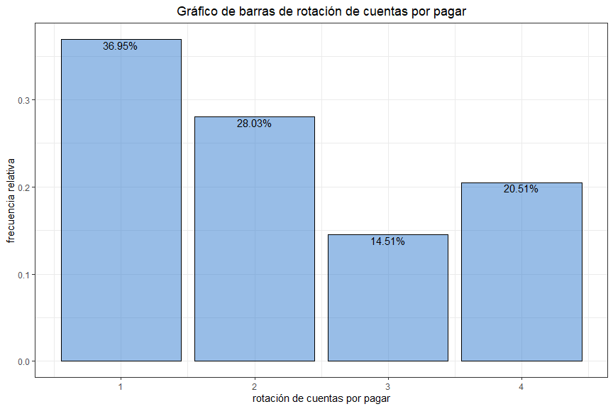

```r
grafico_barras(tabla_frecuencias, "rotación de cuentas por pagar")
```

La variable `rotacion_cxp` representa la rotación de las cuentas por pagar en días para cada empresa, esta se encuentra categorizada de forma ordinal en 4 niveles, donde el nivel 1 simboliza la rotación más corta y el nivel 4 simboliza la más larga, por ello para el análisis se utiliza la siguiente redefinición:

- 1 = Corto
- 2 = Medio corto
- 3 = Medio largo
- 4 = Largo

Del gráfico de barras y la tabla de frecuencias observamos que el 36.95% de las empresas se encuentran agrupadas en el nivel 1 y el 28.03% en el 2, reflejando que el 64.98% se caracterizan por estar en los ciclos más cortos. Por otro lado, en la categoría de los ciclos largos se encuentra el 20.51% de las empresas, y en el ciclo medio largo tan solo el 14.51%.

## 2.11. `ciclo_negocio`

```r
tabla_frecuencias <- crear_tabla(datos_originales, ciclo_negocio)
mostrar_tabla(tabla_frecuencias)
```

| ciclo_negocio | Frecuencia absoluta | Frecuencia absoluta acumulada | Frecuencia relativa | Frecuencia relativa acumulada |
| --- | --- | --- | --- | --- |
| 1 | 152 | 152 | 0.0681 | 0.0681 |
| 2 | 269 | 421 | 0.1205 | 0.1885 |
| 3 | 291 | 712 | 0.1303 | 0.3189 |
| 4 | 511 | 1223 | 0.2288 | 0.5477 |
| 5 | 450 | 1673 | 0.2015 | 0.7492 |
| 6 | 560 | 2233 | 0.2508 | 1.0000 |

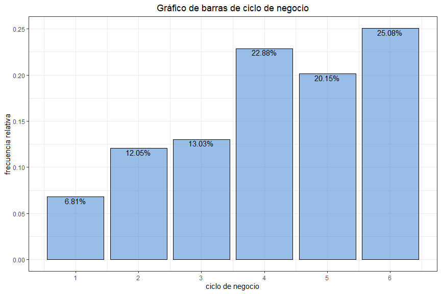

```r
grafico_barras(tabla_frecuencias, "ciclo de negocio")
```

La variable `ciclo_negocio` representa la rotación del ciclo de negocios en días para cada empresa, esta se encuentra categorizada de forma ordinal en 6 niveles, donde el nivel 1 simboliza la rotación más corta y el nivel 6 simboliza la más larga, por ello para el análisis se utiliza la siguiente redefinición:

- 1 = Corto
- 2 = Moderadamente corto
- 3 = Medio corto
- 4 = Medio largo
- 5 = Moderadamente largo
- 6 = Largo

Del gráfico de barras y la tabla de frecuencias observamos que los ciclos de negocio cortos son los menos populares, seguido del moderadamente corto y el medio corto, estos tres primeros niveles representan tan solo al 31.89% de las empresas. Por otro lado, es claro que los ciclos largos (25.08%) son los más comunes.

## 2.12. `ciclo_financiero`

```r
tabla_frecuencias <- crear_tabla(datos_originales, ciclo_financiero)
mostrar_tabla(tabla_frecuencias)
```

| ciclo_financiero | Frecuencia absoluta | Frecuencia absoluta acumulada | Frecuencia relativa | Frecuencia relativa acumulada |
| --- | --- | --- | --- | --- |
| 1 | 269 | 269 | 0.1205 | 0.1205 |
| 2 | 315 | 584 | 0.1411 | 0.2615 |
| 3 | 350 | 934 | 0.1567 | 0.4183 |
| 4 | 282 | 1216 | 0.1263 | 0.5446 |
| 5 | 433 | 1649 | 0.1939 | 0.7385 |
| 6 | 584 | 2233 | 0.2615 | 1.0000 |

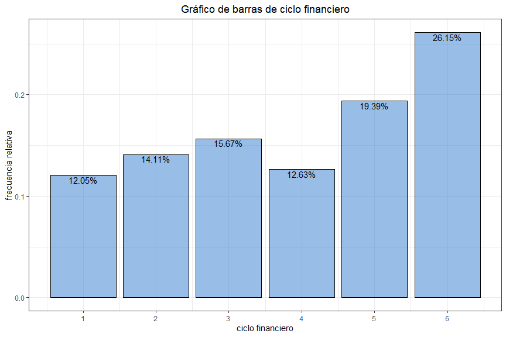

```r
grafico_barras(tabla_frecuencias, "ciclo financiero")
```

La variable `ciclo_financiero` representa la rotación del ciclo financiero en días para cada empresa, esta se encuentra categorizada de forma ordinal en 6 niveles, donde el nivel 1 simboliza la rotación más corta y el nivel 6 simboliza la más larga, por ello para el análisis se utiliza la siguiente redefinición:

- 1 = Corto
- 2 = Moderadamente corto
- 3 = Medio corto
- 4 = Medio largo
- 5 = Moderadamente largo
- 6 = Largo

Del gráfico de barras y la tabla de frecuencias observamos que el 41.83% de las empresas se encuentran en los tres primeros niveles, donde el 12.05% tienen ciclos cortos, el 14.11% ciclos moderadamente cortos y el 15.67% ciclos medio cortos. Por otro lado, se resalta que los ciclos largos (26.15%) son los más populares.

# 3. Variables continuas

## 3.1. `pagos_pj`

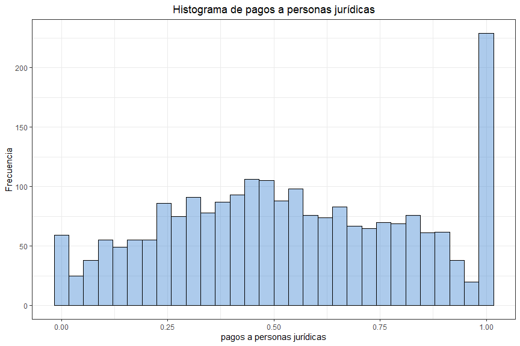

```r
crear_grafico(datos_originales, pagos_pj, 30, "pagos a personas jurídicas")
```

```r
resumen(datos_originales$pagos_pj)
```

| Mínimo | Q1 | Mediana | Media | Q3 | Máximo | Ceros | Proporcion ceros |
| --- | --- | --- | --- | --- | --- | --- | --- |
| 0 | 0.316 | 0.524 | 0.5393 | 0.774 | 1 | 46 | 2.06% |

Del histograma y el resumen numérico se observa que el pago a personas jurídicas es algo frecuente, esto se nota a partir de la proporción de ceros (2.06%), la cual al ser muy baja nos permite confirmar que mas de el 97% de las empresas han realizado este tipo de pagos. Se resalta además que en promedio las empresas destinan a este tipo de transacciones el 53.93% de sus pagos totales.

De la gran similitud entre la media y la mediana se puede concluir que la distribución es aproximadamente simétrica, por lo tanto no presenta valores máximos o mínimos que tengan una fuerte influencia.

## 3.2. `pagos_pn`

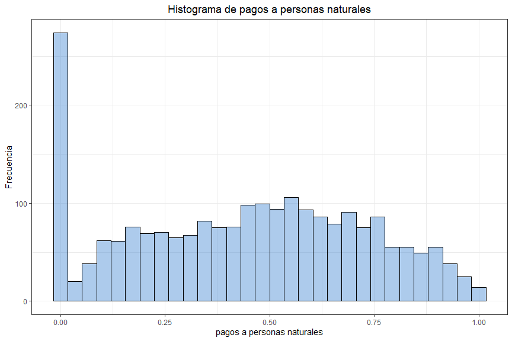

```r
crear_grafico(datos_originales, pagos_pn, 30, "pagos a personas naturales")
```

```r
resumen(datos_originales$pagos_pn)
```

| Mínimo | Q1 | Mediana | Media | Q3 | Máximo | Ceros | Proporcion ceros |
| --- | --- | --- | --- | --- | --- | --- | --- |
| 0 | 0.2 | 0.46 | 0.4406 | 0.665 | 1 | 273 | 12.23% |

Del histograma y el resumen numérico se observa que el pago a personas naturales es menos frecuente que el pago a personas jurídicas, esto se nota a partir de la proporción de ceros (12.23%), la cual es mayor al resultado de la variable anterior, sin embargo sigue siendo moderadamente bajo, concluyendo con esto que el pago a personas naturales es bastante frecuente. Se resalta además que en promedio las empresas destinan a este tipo de transacciones el 44.06% de sus pagos totales.

De la gran similitud entre la media y la mediana se puede concluir que la distribución es aproximadamente simétrica, por lo tanto no presenta valores máximos o mínimos que tengan una fuerte influencia.

## 3.3. `recaudos_pj`

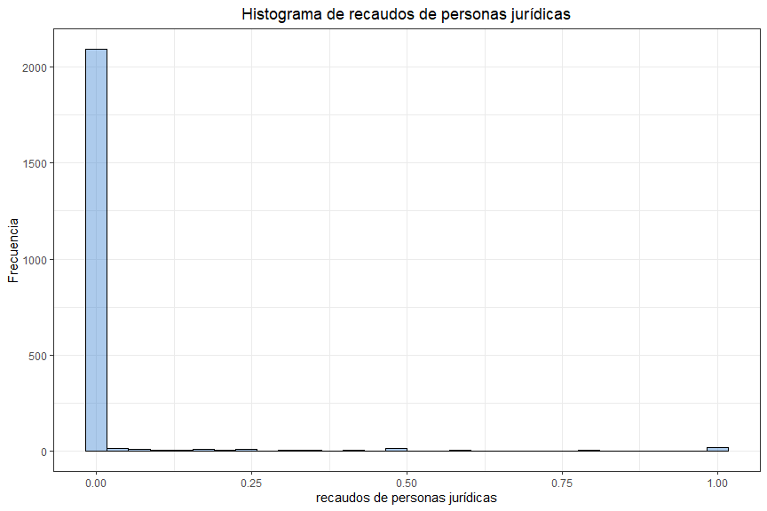

```r
crear_grafico(datos_originales, recaudos_pj, 30, "recaudos de personas jurídicas")
```

```r
resumen(datos_originales$recaudos_pj)
```

| Mínimo | Q1 | Mediana | Media | Q3 | Máximo | Ceros | Proporcion ceros |
| --- | --- | --- | --- | --- | --- | --- | --- |
| 0 | 0 | 0 | 0.0256 | 0 | 1 | 2082 | 93.24% |

Del histograma y el resumen numérico se observa que la proporción de ceros (93.24%) es demasiado alta, llevandonos a concluir que este tipo de transacciones son muy poco frecuentes en las empresas.

## 3.4. `recaudos_pn`

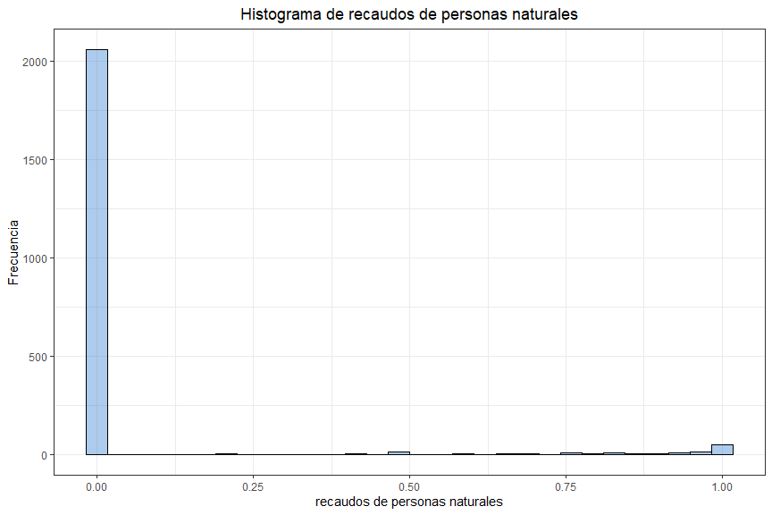

```r
crear_grafico(datos_originales, recaudos_pn, 30, "recaudos de personas naturales")
```

```r
resumen(datos_originales$recaudos_pn)
```

| Mínimo | Q1 | Mediana | Media | Q3 | Máximo | Ceros | Proporcion ceros |
| --- | --- | --- | --- | --- | --- | --- | --- |
| 0 | 0 | 0 | 0.0613 | 0 | 1 | 2058 | 92.16% |

Similar a lo apreciado para la variable anterior, a partir del histograma y el resumen numérico se observa que la proporción de ceros (92.16%) es demasiado alta, llevandonos a concluir que este tipo de transacciones son muy poco frecuentes en las empresas.

# 4. Correlación entre las variables

## 4.1. Categóricas ordinales

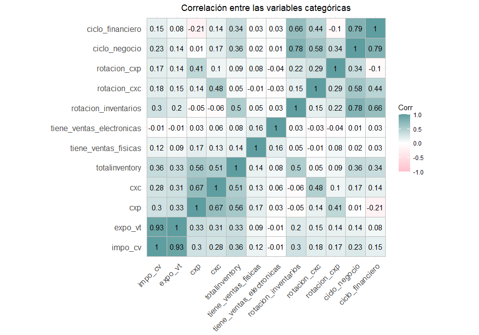

```r
#Se seleccionan las variables categóricas
categoricas <- datos_originales %>% select(!matches("vm|tx|pagos|recaudos|nit"))

#Se calulan las correlaciones entre las variables ordinales
correlaciones <- cor(categoricas, method = "spearman")

#Se muestra el gráfico de correlación
ggcorrplot(correlaciones, lab = TRUE, colors = c("pink",
                                                 "white",
                                                 "cadetblue")
)+
  #Se añade el titulo del gráfico
  ggtitle("Correlación entre las variables categóricas")+
  #Se centra el titulo
  theme(plot.title = element_text(hjust = 0.5))
```

## 4.2. Cotinuas

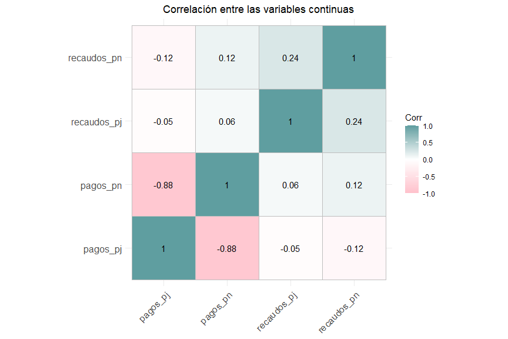

```r
#Se seleccionan las variables continuas
continuas <- datos_originales %>% select(matches("pagos|recaudos"))

#Se calulan las correlaciones entre las variables ordinales
correlaciones <- cor(continuas)

#Se muestra el gráfico de correlación
ggcorrplot(correlaciones, lab = TRUE, colors = c("pink",
                                                 "white",
                                                 "cadetblue")
)+
  #Se añade el titulo del gráfico
  ggtitle("Correlación entre las variables continuas")+
  #Se centra el titulo
  theme(plot.title = element_text(hjust = 0.5))
```